# Example_MetaAnalysis

```r
library(bayesMetaintegrator)
#load practice data
data("test_discovery")
```

# Step 0: Data Loading + Pre-processing

To get data to work with, we need to create a MetaIntegrator object. Details on how to create a MetaIntegrator object can be found in the [MetaIntegrator vignette](https://cran.r-project.org/web/packages/MetaIntegrator/vignettes/MetaIntegrator.html#performing-a-meta-analysis-using-the-metaintegrator-package). For this vignette, we will be using a pre-processed MetaIntegrator object.

```r
library(MetaIntegrator)
MetaIntegrator::checkDataObject(test_discovery, "Meta", "Pre-Analysis")
```

```
#> [1] TRUE
```

## Step 1: Probe to Gene Mapping

Next, for Bayesian meta-analysis, we need to map the probes to the genes. This is done by taking an average level of all the probes for a single gene. This function takes in the MetaIntegrator object and the list of genes we are interested in and converts probes to gene levels within each dataset by taking an average across probes. The results are saved in a new section of the MetaIntegrator object `bayesianMeta`.  
Note: You do need EXPR, CLASSES, PROBES, KEYS for this to run for each dataset.  
**Outputs:**  
`discovery$bayesianMeta$originalData$...$gene_expr`: A data.frame with genes as rows and samples as columns and their mean probe level as values.

```r
geneSubsetList <- c("BRCA1", "TBC1D2", "POSTN", "SERPINB2", "PRR4", "CEACAM5", "KRT6A", "SCGB3A1", "C3", "MUC5B", "VEGFA", "SLC6A4", "FANCI")
test_discovery <- probeToGene(test_discovery, geneSubsetList)
```

## Step 2: Single Dataset Analysis using BEST

Now we get the effect size distribution for each gene in each dataset. This is with the `getDatasetEffectSizes` function. There are a few parameters for this function:  
1) *steps* - the number of steps to run MCMC for each gene.  
2) *burnInSteps* - Number of steps for burn in.  
3) *cores* - Number of cores to use.  
Following this, we can filter the *Rhats* (convergence criteria). The default Rhat filter is 1.1 - however, this can be decreased or increased. If many genes have a high Rhat, consider running the meta-analysis with more steps and more burn-in - this should help the model converge.  
**Outputs**:  
`discovery$bayesianMeta$datasetResults`: A data.frame in long format which has the genes, effect size and std. dev. for each gene. We will use this to run the combined meta-analysis.

```r
test_discovery <- getDatasetEffectSizes(discovery = test_discovery, cores = 2, steps = 2000)
```

```
#> [1] "GSE18965"
#> [1] "GSE41861"
#> [1] "GSE64913"
#> [1] "GSE89809"
#> Warning in getDatasetEffectSizes(discovery = test_discovery, cores =
#> 2, : Warning: Some sigma rhats > 1.1 (1.96078431372549%). Please check
#> $bayesianMeta$datasetResults and consider running with more steps.
```

```r
test_discovery <- filterRhat(test_discovery)
head(test_discovery$bayesianMeta$datasetResults)
```

```
#>                     Gene    effSize    stdDev rhatMeanCases rhatMeanControls
#> BRCA1_GSE18965     BRCA1  1.7094342 0.6696583      1.002224         1.011988
#> C3_GSE18965           C3 -0.4104061 0.5219354      1.002293         1.002753
#> CEACAM5_GSE18965 CEACAM5  0.1901186 0.5103159      1.003683         1.021672
#> FANCI_GSE18965     FANCI  1.1887608 0.6650074      1.011931         1.002795
#> MUC5B_GSE18965     MUC5B -0.7741300 0.6351703      1.000919         1.030367
#> POSTN_GSE18965     POSTN  1.7989225 0.7142183      1.000470         1.002265
#>                  rhatSigmaCases rhatSigmaControl     name
#> BRCA1_GSE18965         1.017517         1.011669 GSE18965
#> C3_GSE18965            1.005177         1.001046 GSE18965
#> CEACAM5_GSE18965       1.003874         1.021329 GSE18965
#> FANCI_GSE18965         1.033064         1.005656 GSE18965
#> MUC5B_GSE18965         1.032300         1.029579 GSE18965
#> POSTN_GSE18965         1.055033         1.016213 GSE18965
```

## Step 3: Run Meta-Analysis using hierarchical model

This step combines the distributions across studies to create a single pooled effect size distribution.  
There are a few parameters for this function:  
1) *Steps* - the number of steps to run MCMC for each gene.  
2) *burnInSteps* - Number of steps for burn in.  
3) *definedModel* - this can be a user supplied JAGs model for the pooling step.  
**Outputs**:  
`discovery$bayesianMeta$finalResults`: A data.frame that contains the gene, final effect size/std.dev, tau/std.dev and probability of the gene’s ES being zero/opposite sign, as well as the convergence estimates for the mean and standard deviation (want this to be near 1 and not over 1.1).  
`discovery$bayesianMeta$pooledResultsDetailed`: A list of data.frames (by gene) that contains detailed results from the pooling step. This includes adjusted effect size estimates, rHats, etc.

```r
test_discovery <- combineDatasets(discovery = test_discovery, steps = 5000, burnIn = 1000)
```

[output not shown]

```r
head(test_discovery$bayesianMeta$finalResults)
```

```
#>       Gene         ES     ES_SD       Tau     TauSD          Pr0 nStudies
#> 1  SCGB3A1 -1.2911936 0.3672991 0.4068316 0.4003679 0.0002195681        3
#> 2    POSTN  0.9975966 0.2863953 0.3633238 0.3662369 0.0002476497        4
#> 3  CEACAM5  1.0821134 0.3644609 0.5488616 0.4351628 0.0014934653        4
#> 4 SERPINB2  1.0449801 0.3642129 0.4458797 0.3958151 0.0020579078        4
#> 5    VEGFA -0.9176188 0.3505786 0.4589809 0.4082361 0.0044295922        4
#> 6     PRR4  1.0403685 0.4080788 0.5378035 0.4103860 0.0053949472        4
#>      ESRhat  TauRhat
#> 1 1.0013527 1.001395
#> 2 1.0030546 1.002104
#> 3 1.0011168 1.025850
#> 4 0.9997893 1.002976
#> 5 1.0024859 1.005191
#> 6 1.0092574 1.000462
```

For debugging the underlying model, we can plot traces to see if there are any convergence issues. This can be done by using the `getCombiningModel` and `getCombineTrace` functions.

```r
#this function returns the JAGs model for the hierarchical model
model <- getCombiningModel(discovery = test_discovery, gene = "BRCA1", steps = 5000, burnIn = 1000)
```

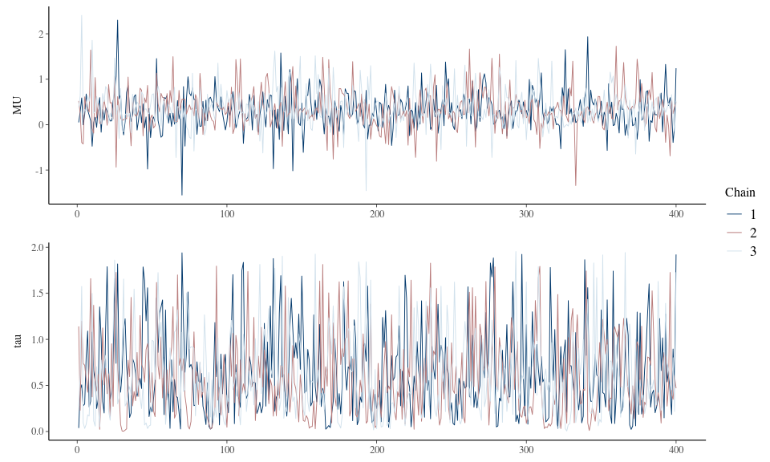

```r
#then can plot the trace (or use other BayesPlot functions)
getCombineTrace(model, parameters = c("MU", "tau"), trace = TRUE)
```

# Step 4: Filter + Vizualize

## filterGenes

This function takes makes a MetaIntegrator Filter object, which can then be used with the various MetaIntegrator [visualization](https://cran.r-project.org/web/packages/MetaIntegrator/vignettes/MetaIntegrator.html#visualization-functions), [validation](https://cran.r-project.org/web/packages/MetaIntegrator/vignettes/MetaIntegrator.html#validation-functions) and [search](https://cran.r-project.org/web/packages/MetaIntegrator/vignettes/MetaIntegrator.html#search-functions) functions.  
Here, we create a filter and then see how well the filter performs seperating classes in the studies.

**Arguments:**  
`discovery`: this is the meta-integrator object we are operating on, post combineDatasets.  
`probabilityThresh`: We will filter down the genes based on probability their effect size = 0. A lower probability is optimal [upper bound].  
`effectSizeThresh`: We will filter down the genes based on effect size point estimate (higher is better) [lower bound].  
`numberStudiesThresh`: We will filter down the genes based on number of studies [lower bound].  
**Outputs:**  
`discovery$filterResults`: All filter objects that you can use with MetaIntegrator’s built in functions will be stored here.

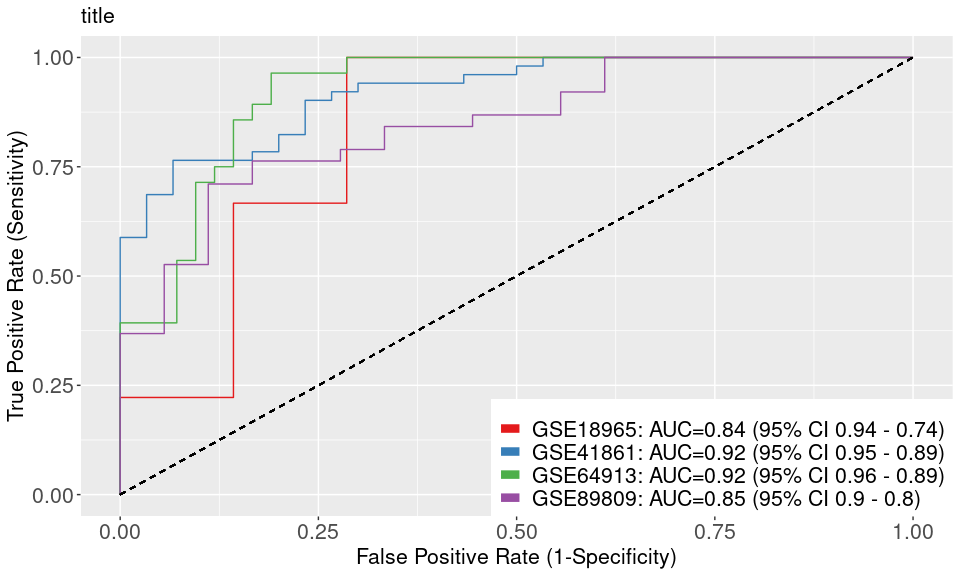

```r
test_discovery <- bayesMetaintegrator::filterGenes(test_discovery, probabilityThresh = .05, effectSizeThresh = .5, numberStudiesThresh = 2)

#and now run the MetaIntegrator functions with the resulting filter objects.
MetaIntegrator::multipleROCPlot(test_discovery, test_discovery$filterResults$bayesian_PR_0.05ES_0.5nStudies_2)
```

## Forest Plots

Some functions do slightly differ, however from the MetaIntegrator functions. One such function is the `forestPlot` function in MetaIntegrator, which is replaced with the `makeBayesianForestPlot` function in bayesMetaIntegrator.

```
#> [1] "character"
```

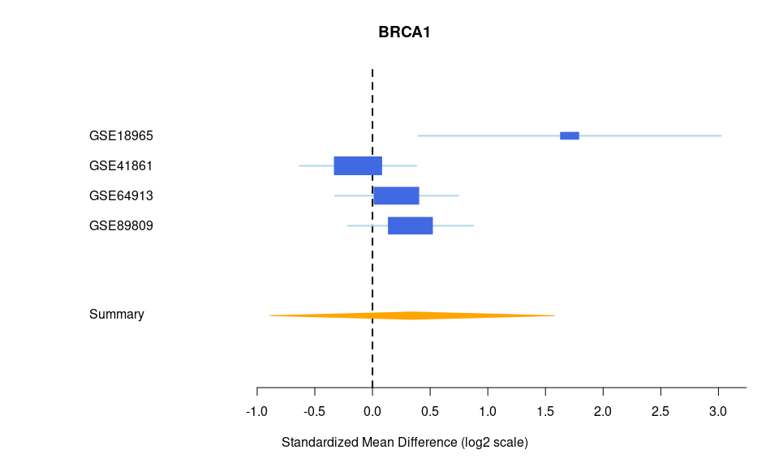

```r
testPlot <- makeBayesianForestPlot(test_discovery, "BRCA1", plotType = "frequentist")
```